# Risk Factor Analysis

## Outcome Variable

**Outcome Variable:** whz

## Predictor Variables

**Intervention Variable:** hhwealth_quart

**Adjustment Set:**

- arm
- sex
- W_mage
- meducyrs
- feducyrs
- W_gagebrth
- W_birthwt
- W_birthlen
- W_nchldlt5
- W_parity
- delta_W_mage
- delta_meducyrs
- delta_feducyrs
- delta_W_gagebrth
- delta_W_birthwt
- delta_W_birthlen
- delta_W_nchldlt5
- delta_W_parity

## Stratifying Variables

The analysis was stratified on these variable(s):

- agecat
- studyid
- country

## Data Summary

| agecat | studyid | country | hhwealth_quart | n_cell | n | outcome_variable |
| --- | --- | --- | --- | --- | --- | --- |
| Birth | CMC-V-BCS-2002 | INDIA | Wealth Q4 | 32 | 86 | whz |
| Birth | CMC-V-BCS-2002 | INDIA | Wealth Q1 | 13 | 86 | whz |
| Birth | CMC-V-BCS-2002 | INDIA | Wealth Q2 | 19 | 86 | whz |
| Birth | CMC-V-BCS-2002 | INDIA | Wealth Q3 | 22 | 86 | whz |
| Birth | COHORTS | GUATEMALA | Wealth Q4 | 258 | 729 | whz |
| Birth | COHORTS | GUATEMALA | Wealth Q1 | 144 | 729 | whz |
| Birth | COHORTS | GUATEMALA | Wealth Q2 | 141 | 729 | whz |
| Birth | COHORTS | GUATEMALA | Wealth Q3 | 186 | 729 | whz |
| Birth | COHORTS | PHILIPPINES | Wealth Q4 | 815 | 2898 | whz |
| Birth | COHORTS | PHILIPPINES | Wealth Q1 | 647 | 2898 | whz |
| Birth | COHORTS | PHILIPPINES | Wealth Q2 | 506 | 2898 | whz |
| Birth | COHORTS | PHILIPPINES | Wealth Q3 | 930 | 2898 | whz |
| Birth | CONTENT | PERU | Wealth Q4 | 0 | 2 | whz |
| Birth | CONTENT | PERU | Wealth Q1 | 0 | 2 | whz |
| Birth | CONTENT | PERU | Wealth Q2 | 1 | 2 | whz |
| Birth | CONTENT | PERU | Wealth Q3 | 1 | 2 | whz |
| Birth | GMS-Nepal | NEPAL | Wealth Q4 | 161 | 641 | whz |
| Birth | GMS-Nepal | NEPAL | Wealth Q1 | 164 | 641 | whz |
| Birth | GMS-Nepal | NEPAL | Wealth Q2 | 160 | 641 | whz |
| Birth | GMS-Nepal | NEPAL | Wealth Q3 | 156 | 641 | whz |
| Birth | IRC | INDIA | Wealth Q4 | 79 | 343 | whz |
| Birth | IRC | INDIA | Wealth Q1 | 90 | 343 | whz |
| Birth | IRC | INDIA | Wealth Q2 | 83 | 343 | whz |
| Birth | IRC | INDIA | Wealth Q3 | 91 | 343 | whz |
| Birth | JiVitA-3 | BANGLADESH | Wealth Q4 | 4505 | 17994 | whz |
| Birth | JiVitA-3 | BANGLADESH | Wealth Q1 | 4435 | 17994 | whz |
| Birth | JiVitA-3 | BANGLADESH | Wealth Q2 | 4476 | 17994 | whz |
| Birth | JiVitA-3 | BANGLADESH | Wealth Q3 | 4578 | 17994 | whz |
| Birth | JiVitA-4 | BANGLADESH | Wealth Q4 | 572 | 2394 | whz |
| Birth | JiVitA-4 | BANGLADESH | Wealth Q1 | 560 | 2394 | whz |

[output cut: 178 more lines]

The following strata were considered:

- agecat: 24 months, studyid: CMC-V-BCS-2002, country: INDIA
- agecat: 24 months, studyid: COHORTS, country: GUATEMALA
- agecat: 24 months, studyid: COHORTS, country: PHILIPPINES
- agecat: 24 months, studyid: CONTENT, country: PERU
- agecat: 24 months, studyid: GMS-Nepal, country: NEPAL
- agecat: 24 months, studyid: IRC, country: INDIA
- agecat: 24 months, studyid: JiVitA-3, country: BANGLADESH
- agecat: 24 months, studyid: JiVitA-4, country: BANGLADESH
- agecat: 24 months, studyid: LCNI-5, country: MALAWI
- agecat: 24 months, studyid: MAL-ED, country: BANGLADESH
- agecat: 24 months, studyid: MAL-ED, country: BRAZIL
- agecat: 24 months, studyid: MAL-ED, country: INDIA
- agecat: 24 months, studyid: MAL-ED, country: NEPAL
- agecat: 24 months, studyid: MAL-ED, country: PERU
- agecat: 24 months, studyid: MAL-ED, country: SOUTH AFRICA
- agecat: 24 months, studyid: MAL-ED, country: TANZANIA, UNITED REPUBLIC OF
- agecat: 24 months, studyid: PROVIDE, country: BANGLADESH
- agecat: 24 months, studyid: TanzaniaChild2, country: TANZANIA, UNITED REPUBLIC OF
- agecat: 6 months, studyid: CMC-V-BCS-2002, country: INDIA
- agecat: 6 months, studyid: COHORTS, country: GUATEMALA
- agecat: 6 months, studyid: COHORTS, country: PHILIPPINES
- agecat: 6 months, studyid: CONTENT, country: PERU
- agecat: 6 months, studyid: GMS-Nepal, country: NEPAL
- agecat: 6 months, studyid: IRC, country: INDIA
- agecat: 6 months, studyid: JiVitA-3, country: BANGLADESH
- agecat: 6 months, studyid: JiVitA-4, country: BANGLADESH
- agecat: 6 months, studyid: LCNI-5, country: MALAWI
- agecat: 6 months, studyid: MAL-ED, country: BANGLADESH
- agecat: 6 months, studyid: MAL-ED, country: BRAZIL
- agecat: 6 months, studyid: MAL-ED, country: INDIA
- agecat: 6 months, studyid: MAL-ED, country: NEPAL
- agecat: 6 months, studyid: MAL-ED, country: PERU
- agecat: 6 months, studyid: MAL-ED, country: SOUTH AFRICA
- agecat: 6 months, studyid: MAL-ED, country: TANZANIA, UNITED REPUBLIC OF
- agecat: 6 months, studyid: PROVIDE, country: BANGLADESH
- agecat: 6 months, studyid: TanzaniaChild2, country: TANZANIA, UNITED REPUBLIC OF
- agecat: Birth, studyid: CMC-V-BCS-2002, country: INDIA
- agecat: Birth, studyid: COHORTS, country: GUATEMALA
- agecat: Birth, studyid: COHORTS, country: PHILIPPINES
- agecat: Birth, studyid: CONTENT, country: PERU
- agecat: Birth, studyid: GMS-Nepal, country: NEPAL
- agecat: Birth, studyid: IRC, country: INDIA
- agecat: Birth, studyid: JiVitA-3, country: BANGLADESH
- agecat: Birth, studyid: JiVitA-4, country: BANGLADESH
- agecat: Birth, studyid: MAL-ED, country: BANGLADESH
- agecat: Birth, studyid: MAL-ED, country: BRAZIL
- agecat: Birth, studyid: MAL-ED, country: INDIA
- agecat: Birth, studyid: MAL-ED, country: NEPAL
- agecat: Birth, studyid: MAL-ED, country: PERU
- agecat: Birth, studyid: MAL-ED, country: SOUTH AFRICA
- agecat: Birth, studyid: MAL-ED, country: TANZANIA, UNITED REPUBLIC OF
- agecat: Birth, studyid: PROVIDE, country: BANGLADESH

### Dropped Strata

Some strata were dropped due to rare outcomes:

- agecat: Birth, studyid: CONTENT, country: PERU
- agecat: Birth, studyid: MAL-ED, country: NEPAL
- agecat: 24 months, studyid: TanzaniaChild2, country: TANZANIA, UNITED REPUBLIC OF

## Methods Detail

We’re interested in the causal parameters $E[Y_a]$ for all values of $a \in \mathcal{A}$. These parameters represent the mean outcome if, possibly contrary to fact, we intervened to set all units to have $A=a$. Under the randomization and positivity assumptions, these are identified by the statistical parameters $\psi_a=E_W[E_{Y|A,W}(Y|A=a,W)]$. In addition, we’re interested in the mean of $Y$, $E[Y]$ under no intervention (the observed mean). We will estimate these parameters by using SuperLearner to fit the relevant likelihood factors – $E_{Y|A,W}(Y|A=a,W)$ and $p(A=a|W)$, and then updating our likelihood fit using a joint TMLE.

For unadjusted analyses ($W=\{\}$), initial likelihoods were estimated using Lrnr_glm to estimate the simple $E(Y|A)$ and Lrnr_mean to estimate $p(A)$. For adjusted analyses, a small library containing Lrnr_glmnet, Lrnr_xgboost, and Lrnr_mean was used.

Having estimated these parameters, we will then use the delta method to estimate relative risks and attributable risks relative to a prespecified baseline level of $A$.

# Results Detail

## Results Plots

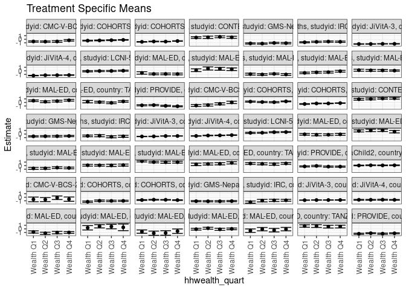

[figure not shown]

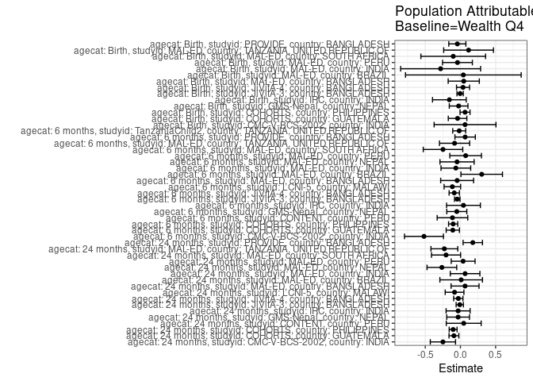

## Results Table

### Parameter: TSM

| agecat | studyid | country | intervention_level | baseline_level | estimate | ci_lower | ci_upper |
| --- | --- | --- | --- | --- | --- | --- | --- |
| Birth | CMC-V-BCS-2002 | INDIA | Wealth Q4 | NA | -0.5304685 | -1.1405593 | 0.0796222 |
| Birth | CMC-V-BCS-2002 | INDIA | Wealth Q1 | NA | -0.6030988 | -1.2614957 | 0.0552981 |
| Birth | CMC-V-BCS-2002 | INDIA | Wealth Q2 | NA | -0.6502473 | -1.2264124 | -0.0740822 |
| Birth | CMC-V-BCS-2002 | INDIA | Wealth Q3 | NA | -0.1424090 | -0.6385521 | 0.3537340 |
| Birth | COHORTS | GUATEMALA | Wealth Q4 | NA | -1.0166309 | -1.1921836 | -0.8410782 |
| Birth | COHORTS | GUATEMALA | Wealth Q1 | NA | -1.2544714 | -1.4551087 | -1.0538341 |
| Birth | COHORTS | GUATEMALA | Wealth Q2 | NA | -0.9920482 | -1.2051544 | -0.7789420 |
| Birth | COHORTS | GUATEMALA | Wealth Q3 | NA | -1.0249723 | -1.2247456 | -0.8251990 |
| Birth | COHORTS | PHILIPPINES | Wealth Q4 | NA | -0.8076370 | -0.8924361 | -0.7228379 |
| Birth | COHORTS | PHILIPPINES | Wealth Q1 | NA | -0.7782722 | -0.8795939 | -0.6769505 |
| Birth | COHORTS | PHILIPPINES | Wealth Q2 | NA | -0.6882990 | -0.7961821 | -0.5804158 |
| Birth | COHORTS | PHILIPPINES | Wealth Q3 | NA | -0.7120467 | -0.7907340 | -0.6333595 |
| Birth | GMS-Nepal | NEPAL | Wealth Q4 | NA | -1.0906498 | -1.2462535 | -0.9350461 |
| Birth | GMS-Nepal | NEPAL | Wealth Q1 | NA | -1.1044287 | -1.2608128 | -0.9480446 |
| Birth | GMS-Nepal | NEPAL | Wealth Q2 | NA | -1.1366280 | -1.2950147 | -0.9782413 |
| Birth | GMS-Nepal | NEPAL | Wealth Q3 | NA | -1.1388285 | -1.3143084 | -0.9633487 |
| Birth | IRC | INDIA | Wealth Q4 | NA | -0.8533973 | -1.1264027 | -0.5803918 |
| Birth | IRC | INDIA | Wealth Q1 | NA | -1.3619616 | -1.6719206 | -1.0520025 |
| Birth | IRC | INDIA | Wealth Q2 | NA | -0.9442924 | -1.3009061 | -0.5876787 |
| Birth | IRC | INDIA | Wealth Q3 | NA | -0.8725037 | -1.1971018 | -0.5479057 |
| Birth | JiVitA-3 | BANGLADESH | Wealth Q4 | NA | -0.7732368 | -0.8236143 | -0.7228593 |
| Birth | JiVitA-3 | BANGLADESH | Wealth Q1 | NA | -0.8195046 | -0.8599255 | -0.7790838 |
| Birth | JiVitA-3 | BANGLADESH | Wealth Q2 | NA | -0.7808804 | -0.8162918 | -0.7454689 |
| Birth | JiVitA-3 | BANGLADESH | Wealth Q3 | NA | -0.7800393 | -0.8131344 | -0.7469442 |
| Birth | JiVitA-4 | BANGLADESH | Wealth Q4 | NA | -0.7254010 | -0.8293138 | -0.6214882 |
| Birth | JiVitA-4 | BANGLADESH | Wealth Q1 | NA | -0.7152447 | -0.8346423 | -0.5958471 |
| Birth | JiVitA-4 | BANGLADESH | Wealth Q2 | NA | -0.7151579 | -0.8253344 | -0.6049815 |
| Birth | JiVitA-4 | BANGLADESH | Wealth Q3 | NA | -0.6915130 | -0.8299398 | -0.5530862 |
| Birth | MAL-ED | BANGLADESH | Wealth Q4 | NA | -1.0201072 | -1.2633591 | -0.7768553 |
| Birth | MAL-ED | BANGLADESH | Wealth Q1 | NA | -0.8795292 | -1.1923200 | -0.5667384 |

[output cut: 166 more lines]

### Parameter: E(Y)

| agecat | studyid | country | intervention_level | baseline_level | estimate | ci_lower | ci_upper |
| --- | --- | --- | --- | --- | --- | --- | --- |
| Birth | CMC-V-BCS-2002 | INDIA | NA | NA | -0.4648256 | -0.7643210 | -0.1653302 |
| Birth | COHORTS | GUATEMALA | NA | NA | -1.0572840 | -1.1606089 | -0.9539590 |
| Birth | COHORTS | PHILIPPINES | NA | NA | -0.7422912 | -0.7886598 | -0.6959226 |
| Birth | GMS-Nepal | NEPAL | NA | NA | -1.1164431 | -1.2040134 | -1.0288728 |
| Birth | IRC | INDIA | NA | NA | -1.0105831 | -1.1973019 | -0.8238643 |
| Birth | JiVitA-3 | BANGLADESH | NA | NA | -0.7777103 | -0.7967006 | -0.7587201 |
| Birth | JiVitA-4 | BANGLADESH | NA | NA | -0.6882498 | -0.7406539 | -0.6358456 |
| Birth | MAL-ED | BANGLADESH | NA | NA | -0.9728358 | -1.1217009 | -0.8239707 |
| Birth | MAL-ED | BRAZIL | NA | NA | 0.4643860 | 0.1360519 | 0.7927200 |
| Birth | MAL-ED | INDIA | NA | NA | -0.9441026 | -1.2397919 | -0.6484132 |
| Birth | MAL-ED | PERU | NA | NA | -0.0468095 | -0.1738806 | 0.0802616 |
| Birth | MAL-ED | SOUTH AFRICA | NA | NA | -0.1729474 | -0.4186222 | 0.0727275 |
| Birth | MAL-ED | TANZANIA, UNITED REPUBLIC OF | NA | NA | 0.7637500 | 0.5676177 | 0.9598823 |
| Birth | PROVIDE | BANGLADESH | NA | NA | -1.2984586 | -1.3752758 | -1.2216415 |
| 6 months | CMC-V-BCS-2002 | INDIA | NA | NA | -0.5026766 | -0.6536848 | -0.3516685 |
| 6 months | COHORTS | GUATEMALA | NA | NA | 0.1914471 | 0.1185005 | 0.2643936 |
| 6 months | COHORTS | PHILIPPINES | NA | NA | -0.2938433 | -0.3352064 | -0.2524802 |
| 6 months | CONTENT | PERU | NA | NA | 1.0644279 | 0.9468682 | 1.1819876 |
| 6 months | GMS-Nepal | NEPAL | NA | NA | -0.6038416 | -0.6899448 | -0.5177384 |
| 6 months | IRC | INDIA | NA | NA | -0.5989297 | -0.7344491 | -0.4634104 |
| 6 months | JiVitA-3 | BANGLADESH | NA | NA | -0.5932502 | -0.6127743 | -0.5737261 |
| 6 months | JiVitA-4 | BANGLADESH | NA | NA | -0.3901595 | -0.4274150 | -0.3529041 |
| 6 months | LCNI-5 | MALAWI | NA | NA | 0.4417647 | 0.3702742 | 0.5132552 |
| 6 months | MAL-ED | BANGLADESH | NA | NA | -0.1333333 | -0.2623761 | -0.0042906 |
| 6 months | MAL-ED | BRAZIL | NA | NA | 0.9720774 | 0.8078144 | 1.1363403 |
| 6 months | MAL-ED | INDIA | NA | NA | -0.7102872 | -0.8371659 | -0.5834085 |
| 6 months | MAL-ED | NEPAL | NA | NA | 0.1104308 | -0.0208643 | 0.2417259 |
| 6 months | MAL-ED | PERU | NA | NA | 1.0512099 | 0.9285617 | 1.1738581 |
| 6 months | MAL-ED | SOUTH AFRICA | NA | NA | 0.5404351 | 0.3867005 | 0.6941696 |
| 6 months | MAL-ED | TANZANIA, UNITED REPUBLIC OF | NA | NA | 0.5362213 | 0.4049390 | 0.6675036 |
| 6 months | PROVIDE | BANGLADESH | NA | NA | -0.1990907 | -0.2817968 | -0.1163845 |
| 6 months | TanzaniaChild2 | TANZANIA, UNITED REPUBLIC OF | NA | NA | 0.0801680 | 0.0273223 | 0.1330136 |
| 24 months | CMC-V-BCS-2002 | INDIA | NA | NA | -0.5571505 | -0.6585247 | -0.4557763 |
| 24 months | COHORTS | GUATEMALA | NA | NA | -0.2791396 | -0.3336899 | -0.2245893 |
| 24 months | COHORTS | PHILIPPINES | NA | NA | -0.6099592 | -0.6467541 | -0.5731643 |
| 24 months | CONTENT | PERU | NA | NA | 0.5902439 | 0.4560143 | 0.7244735 |
| 24 months | GMS-Nepal | NEPAL | NA | NA | -1.1363107 | -1.2252817 | -1.0473398 |
| 24 months | IRC | INDIA | NA | NA | -0.7458150 | -0.8368180 | -0.6548120 |
| 24 months | JiVitA-3 | BANGLADESH | NA | NA | -1.2973086 | -1.3206115 | -1.2740057 |
| 24 months | JiVitA-4 | BANGLADESH | NA | NA | -1.2231776 | -1.2550332 | -1.1913220 |
| 24 months | LCNI-5 | MALAWI | NA | NA | -0.0477867 | -0.1301103 | 0.0345368 |
| 24 months | MAL-ED | BANGLADESH | NA | NA | -0.8192925 | -0.9412667 | -0.6973182 |
| 24 months | MAL-ED | BRAZIL | NA | NA | 0.4626233 | 0.2567495 | 0.6684971 |
| 24 months | MAL-ED | INDIA | NA | NA | -0.9516520 | -1.0670654 | -0.8362385 |
| 24 months | MAL-ED | NEPAL | NA | NA | -0.3749123 | -0.4886073 | -0.2612173 |
| 24 months | MAL-ED | PERU | NA | NA | 0.1111982 | -0.0118399 | 0.2342362 |
| 24 months | MAL-ED | SOUTH AFRICA | NA | NA | 0.4090301 | 0.2879441 | 0.5301161 |
| 24 months | MAL-ED | TANZANIA, UNITED REPUBLIC OF | NA | NA | 0.0547975 | -0.0703378 | 0.1799328 |
| 24 months | PROVIDE | BANGLADESH | NA | NA | -0.8928670 | -0.9755153 | -0.8102187 |

### Parameter: ATE

| agecat | studyid | country | intervention_level | baseline_level | estimate | ci_lower | ci_upper |
| --- | --- | --- | --- | --- | --- | --- | --- |
| Birth | CMC-V-BCS-2002 | INDIA | Wealth Q4 | Wealth Q4 | 0.0000000 | 0.0000000 | 0.0000000 |
| Birth | CMC-V-BCS-2002 | INDIA | Wealth Q1 | Wealth Q4 | -0.0726303 | -0.9736135 | 0.8283529 |
| Birth | CMC-V-BCS-2002 | INDIA | Wealth Q2 | Wealth Q4 | -0.1197788 | -0.9644892 | 0.7249316 |
| Birth | CMC-V-BCS-2002 | INDIA | Wealth Q3 | Wealth Q4 | 0.3880595 | -0.3955581 | 1.1716771 |
| Birth | COHORTS | GUATEMALA | Wealth Q4 | Wealth Q4 | 0.0000000 | 0.0000000 | 0.0000000 |
| Birth | COHORTS | GUATEMALA | Wealth Q1 | Wealth Q4 | -0.2378404 | -0.4972632 | 0.0215823 |
| Birth | COHORTS | GUATEMALA | Wealth Q2 | Wealth Q4 | 0.0245827 | -0.2441199 | 0.2932853 |
| Birth | COHORTS | GUATEMALA | Wealth Q3 | Wealth Q4 | -0.0083414 | -0.2660902 | 0.2494075 |
| Birth | COHORTS | PHILIPPINES | Wealth Q4 | Wealth Q4 | 0.0000000 | 0.0000000 | 0.0000000 |
| Birth | COHORTS | PHILIPPINES | Wealth Q1 | Wealth Q4 | 0.0293648 | -0.1008277 | 0.1595574 |
| Birth | COHORTS | PHILIPPINES | Wealth Q2 | Wealth Q4 | 0.1193381 | -0.0160978 | 0.2547739 |
| Birth | COHORTS | PHILIPPINES | Wealth Q3 | Wealth Q4 | 0.0955903 | -0.0179240 | 0.2091046 |
| Birth | GMS-Nepal | NEPAL | Wealth Q4 | Wealth Q4 | 0.0000000 | 0.0000000 | 0.0000000 |
| Birth | GMS-Nepal | NEPAL | Wealth Q1 | Wealth Q4 | -0.0137789 | -0.2269479 | 0.1993901 |
| Birth | GMS-Nepal | NEPAL | Wealth Q2 | Wealth Q4 | -0.0459782 | -0.2603143 | 0.1683578 |
| Birth | GMS-Nepal | NEPAL | Wealth Q3 | Wealth Q4 | -0.0481788 | -0.2752926 | 0.1789351 |
| Birth | IRC | INDIA | Wealth Q4 | Wealth Q4 | 0.0000000 | 0.0000000 | 0.0000000 |
| Birth | IRC | INDIA | Wealth Q1 | Wealth Q4 | -0.5085643 | -0.8951629 | -0.1219657 |
| Birth | IRC | INDIA | Wealth Q2 | Wealth Q4 | -0.0908951 | -0.5136742 | 0.3318840 |
| Birth | IRC | INDIA | Wealth Q3 | Wealth Q4 | -0.0191065 | -0.4152343 | 0.3770214 |
| Birth | JiVitA-3 | BANGLADESH | Wealth Q4 | Wealth Q4 | 0.0000000 | 0.0000000 | 0.0000000 |
| Birth | JiVitA-3 | BANGLADESH | Wealth Q1 | Wealth Q4 | -0.0462679 | -0.1072162 | 0.0146805 |
| Birth | JiVitA-3 | BANGLADESH | Wealth Q2 | Wealth Q4 | -0.0076436 | -0.0673196 | 0.0520324 |
| Birth | JiVitA-3 | BANGLADESH | Wealth Q3 | Wealth Q4 | -0.0068025 | -0.0639023 | 0.0502973 |
| Birth | JiVitA-4 | BANGLADESH | Wealth Q4 | Wealth Q4 | 0.0000000 | 0.0000000 | 0.0000000 |
| Birth | JiVitA-4 | BANGLADESH | Wealth Q1 | Wealth Q4 | 0.0101563 | -0.1450624 | 0.1653751 |
| Birth | JiVitA-4 | BANGLADESH | Wealth Q2 | Wealth Q4 | 0.0102431 | -0.1410719 | 0.1615580 |
| Birth | JiVitA-4 | BANGLADESH | Wealth Q3 | Wealth Q4 | 0.0338880 | -0.1380435 | 0.2058196 |
| Birth | MAL-ED | BANGLADESH | Wealth Q4 | Wealth Q4 | 0.0000000 | 0.0000000 | 0.0000000 |
| Birth | MAL-ED | BANGLADESH | Wealth Q1 | Wealth Q4 | 0.1405780 | -0.2541571 | 0.5353131 |

[output cut: 166 more lines]

### Parameter: PAR

| agecat | studyid | country | intervention_level | baseline_level | estimate | ci_lower | ci_upper |
| --- | --- | --- | --- | --- | --- | --- | --- |
| Birth | CMC-V-BCS-2002 | INDIA | Wealth Q4 | NA | 0.0656429 | -0.3741551 | 0.5054410 |
| Birth | COHORTS | GUATEMALA | Wealth Q4 | NA | -0.0406530 | -0.1727141 | 0.0914081 |
| Birth | COHORTS | PHILIPPINES | Wealth Q4 | NA | 0.0653458 | -0.0057155 | 0.1364071 |
| Birth | GMS-Nepal | NEPAL | Wealth Q4 | NA | -0.0257933 | -0.1584579 | 0.1068714 |
| Birth | IRC | INDIA | Wealth Q4 | NA | -0.1571858 | -0.3968400 | 0.0824684 |
| Birth | JiVitA-3 | BANGLADESH | Wealth Q4 | NA | -0.0044736 | -0.0494322 | 0.0404850 |
| Birth | JiVitA-4 | BANGLADESH | Wealth Q4 | NA | 0.0371512 | -0.0555651 | 0.1298675 |
| Birth | MAL-ED | BANGLADESH | Wealth Q4 | NA | 0.0472714 | -0.1743067 | 0.2688494 |
| Birth | MAL-ED | BRAZIL | Wealth Q4 | NA | 0.0414721 | -0.7809061 | 0.8638504 |
| Birth | MAL-ED | INDIA | Wealth Q4 | NA | -0.2816026 | -0.8500282 | 0.2868230 |
| Birth | MAL-ED | PERU | Wealth Q4 | NA | -0.0420527 | -0.2539259 | 0.1698204 |
| Birth | MAL-ED | SOUTH AFRICA | Wealth Q4 | NA | -0.1022733 | -0.5622072 | 0.3576607 |
| Birth | MAL-ED | TANZANIA, UNITED REPUBLIC OF | Wealth Q4 | NA | 0.1157951 | -0.2376467 | 0.4692370 |
| Birth | PROVIDE | BANGLADESH | Wealth Q4 | NA | -0.0439354 | -0.1654886 | 0.0776178 |
| 6 months | CMC-V-BCS-2002 | INDIA | Wealth Q4 | NA | -0.5181947 | -0.7954012 | -0.2409882 |
| 6 months | COHORTS | GUATEMALA | Wealth Q4 | NA | -0.1085414 | -0.2027960 | -0.0142869 |
| 6 months | COHORTS | PHILIPPINES | Wealth Q4 | NA | -0.1034100 | -0.1685756 | -0.0382444 |
| 6 months | CONTENT | PERU | Wealth Q4 | NA | -0.1132658 | -0.3306560 | 0.1041244 |
| 6 months | GMS-Nepal | NEPAL | Wealth Q4 | NA | -0.0515571 | -0.1939921 | 0.0908779 |
| 6 months | IRC | INDIA | Wealth Q4 | NA | 0.0432290 | -0.1971611 | 0.2836191 |
| 6 months | JiVitA-3 | BANGLADESH | Wealth Q4 | NA | -0.0449771 | -0.0838552 | -0.0060990 |
| 6 months | JiVitA-4 | BANGLADESH | Wealth Q4 | NA | -0.0877831 | -0.1609583 | -0.0146078 |
| 6 months | LCNI-5 | MALAWI | Wealth Q4 | NA | -0.1148317 | -0.2321637 | 0.0025002 |
| 6 months | MAL-ED | BANGLADESH | Wealth Q4 | NA | -0.0468850 | -0.2810280 | 0.1872579 |
| 6 months | MAL-ED | BRAZIL | Wealth Q4 | NA | 0.3025256 | 0.0069697 | 0.5980815 |
| 6 months | MAL-ED | INDIA | Wealth Q4 | NA | -0.0651593 | -0.2763281 | 0.1460095 |
| 6 months | MAL-ED | NEPAL | Wealth Q4 | NA | -0.0480765 | -0.2909410 | 0.1947880 |
| 6 months | MAL-ED | PERU | Wealth Q4 | NA | 0.0740626 | -0.1509656 | 0.2990907 |
| 6 months | MAL-ED | SOUTH AFRICA | Wealth Q4 | NA | -0.2477943 | -0.5288606 | 0.0332721 |
| 6 months | MAL-ED | TANZANIA, UNITED REPUBLIC OF | Wealth Q4 | NA | -0.0832946 | -0.2976853 | 0.1310961 |
| 6 months | PROVIDE | BANGLADESH | Wealth Q4 | NA | 0.0670827 | -0.0779838 | 0.2121493 |
| 6 months | TanzaniaChild2 | TANZANIA, UNITED REPUBLIC OF | Wealth Q4 | NA | -0.0173015 | -0.1093290 | 0.0747259 |
| 24 months | CMC-V-BCS-2002 | INDIA | Wealth Q4 | NA | -0.2490331 | -0.4285842 | -0.0694820 |
| 24 months | COHORTS | GUATEMALA | Wealth Q4 | NA | -0.0924851 | -0.1624771 | -0.0224932 |
| 24 months | COHORTS | PHILIPPINES | Wealth Q4 | NA | -0.1036650 | -0.1597843 | -0.0475457 |
| 24 months | CONTENT | PERU | Wealth Q4 | NA | 0.0468226 | -0.2013083 | 0.2949536 |
| 24 months | GMS-Nepal | NEPAL | Wealth Q4 | NA | -0.0329823 | -0.1944783 | 0.1285137 |
| 24 months | IRC | INDIA | Wealth Q4 | NA | -0.0331980 | -0.2038926 | 0.1374966 |
| 24 months | JiVitA-3 | BANGLADESH | Wealth Q4 | NA | -0.0095972 | -0.0611027 | 0.0419083 |
| 24 months | JiVitA-4 | BANGLADESH | Wealth Q4 | NA | -0.0302527 | -0.0963704 | 0.0358650 |
| 24 months | LCNI-5 | MALAWI | Wealth Q4 | NA | -0.0833845 | -0.2164330 | 0.0496639 |
| 24 months | MAL-ED | BANGLADESH | Wealth Q4 | NA | 0.0655373 | -0.1334964 | 0.2645710 |
| 24 months | MAL-ED | BRAZIL | Wealth Q4 | NA | 0.0106108 | -0.2920680 | 0.3132896 |
| 24 months | MAL-ED | INDIA | Wealth Q4 | NA | 0.0663021 | -0.1444311 | 0.2770353 |
| 24 months | MAL-ED | NEPAL | Wealth Q4 | NA | -0.2637877 | -0.4748822 | -0.0526933 |
| 24 months | MAL-ED | PERU | Wealth Q4 | NA | 0.0385329 | -0.1311871 | 0.2082528 |
| 24 months | MAL-ED | SOUTH AFRICA | Wealth Q4 | NA | -0.2045312 | -0.4114875 | 0.0024250 |
| 24 months | MAL-ED | TANZANIA, UNITED REPUBLIC OF | Wealth Q4 | NA | -0.2282949 | -0.4189472 | -0.0376425 |
| 24 months | PROVIDE | BANGLADESH | Wealth Q4 | NA | 0.1757786 | 0.0381030 | 0.3134541 |